# Data Analysis

Garen Bainbridge

2025-11-15

```r
#Loads the required R packages
library(tidyverse)
library(lme4)
library(lmerTest)
library(emmeans)
#Loads the processed HEP data set
long_HEPdata <- read.csv("long_HEPdata.csv")
glimpse(long_HEPdata)
```

```
## Rows: 720
## Columns: 8
## $ Participant                   <chr> "WS001", "WS001", "WS001", "WS001", "WS0…
## $ Condition                     <chr> "low_trial_1", "low_trial_1", "low_trial…
## $ X50.250ms_mean_over_channels  <dbl> -1.9640146, -1.9640146, -1.9640146, -1.9…
## $ X250.400ms_mean_over_channels <dbl> -0.1714064, -0.1714064, -0.1714064, -0.1…
## $ Time_Window                   <chr> "50-250ms", "50-250ms", "50-250ms", "50-…
## $ Channel                       <chr> "ch3", "ch4", "ch12", "ch13", "ch3", "ch…
## $ HEP_mean_value                <dbl> -2.03867480, -1.81106220, -2.29357120, -…
## $ Subject                       <chr> "WS001", "WS001", "WS001", "WS001", "WS0…
```

```r
#Fits the long_HEPdata data set to a LMM with random intercepts only
model1 <- lmer(
  HEP_mean_value ~ Condition * Time_Window + Channel +
    (1 | Participant),
    data = long_HEPdata
)

#Outputs the model summary
summary(model1)
```

```
## Linear mixed model fit by REML. t-tests use Satterthwaite's method [
## lmerModLmerTest]
## Formula: HEP_mean_value ~ Condition * Time_Window + Channel + (1 | Participant)
##    Data: long_HEPdata
##
## REML criterion at convergence: 2713.9
##
## Scaled residuals:
##     Min      1Q  Median      3Q     Max
## -3.4746 -0.5579 -0.0304  0.5040  3.1954
##
## Random effects:
##  Groups      Name        Variance Std.Dev.
##  Participant (Intercept) 0.1234   0.3513
##  Residual                2.4534   1.5663
## Number of obs: 720, groups:  Participant, 15
##
## Fixed effects:
##                                             Estimate Std. Error         df
## (Intercept)                                 0.242262   0.243598 271.626353
## Conditionhigh_trial_2                      -0.270927   0.285971 691.000000
## Conditionlow_trial_1                       -0.123045   0.285971 691.000000
## Conditionlow_trial_2                       -0.508995   0.285971 691.000000
## Conditionmed_trial_1                       -0.671361   0.285971 691.000000
## Conditionmed_trial_2                       -0.988029   0.285971 691.000000
## Time_Window50-250ms                        -0.311054   0.285971 691.000000
## Channelch13                                 0.018313   0.165105 691.000000
## Channelch3                                  0.007894   0.165105 691.000000
## Channelch4                                  0.072671   0.165105 691.000000
## Conditionhigh_trial_2:Time_Window50-250ms   0.352554   0.404423 691.000000
## Conditionlow_trial_1:Time_Window50-250ms    1.026540   0.404423 691.000000
## Conditionlow_trial_2:Time_Window50-250ms    0.841781   0.404423 691.000000
## Conditionmed_trial_1:Time_Window50-250ms    1.122275   0.404423 691.000000
## Conditionmed_trial_2:Time_Window50-250ms    0.787977   0.404423 691.000000
##                                           t value Pr(>|t|)
## (Intercept)                                 0.995 0.320856
## Conditionhigh_trial_2                      -0.947 0.343768
## Conditionlow_trial_1                       -0.430 0.667132
## Conditionlow_trial_2                       -1.780 0.075534 .
## Conditionmed_trial_1                       -2.348 0.019173 *
## Conditionmed_trial_2                       -3.455 0.000584 ***
## Time_Window50-250ms                        -1.088 0.277101
## Channelch13                                 0.111 0.911716
## Channelch3                                  0.048 0.961879
## Channelch4                                  0.440 0.659966
## Conditionhigh_trial_2:Time_Window50-250ms   0.872 0.383650
## Conditionlow_trial_1:Time_Window50-250ms    2.538 0.011358 *
## Conditionlow_trial_2:Time_Window50-250ms    2.081 0.037762 *
## Conditionmed_trial_1:Time_Window50-250ms    2.775 0.005669 **
## Conditionmed_trial_2:Time_Window50-250ms    1.948 0.051772 .
## ---
## Signif. codes:  0 '***' 0.001 '**' 0.01 '*' 0.05 '.' 0.1 ' ' 1
```

```
##
## Correlation matrix not shown by default, as p = 15 > 12.
## Use print(x, correlation=TRUE)  or
##     vcov(x)        if you need it
```

```r
#Fits the long_HEPdata data set to a LMM with random intercepts and random slopes
model2 <- lmer(
  HEP_mean_value ~ Condition * Time_Window + Channel +
    (1 + Time_Window | Participant),
    data = long_HEPdata
)
#Outputs the model summary and type 3 ANOVA
summary(model2)
```

```
## Linear mixed model fit by REML. t-tests use Satterthwaite's method [
## lmerModLmerTest]
## Formula:
## HEP_mean_value ~ Condition * Time_Window + Channel + (1 + Time_Window |
##     Participant)
##    Data: long_HEPdata
##
## REML criterion at convergence: 2628.7
##
## Scaled residuals:
##     Min      1Q  Median      3Q     Max
## -3.1800 -0.6077 -0.0295  0.5566  3.3198
##
## Random effects:
##  Groups      Name                Variance Std.Dev. Corr
##  Participant (Intercept)         0.6669   0.8166
##              Time_Window50-250ms 1.5664   1.2515   -0.91
##  Residual                        2.0726   1.4396
## Number of obs: 720, groups:  Participant, 15
##
## Fixed effects:
##                                             Estimate Std. Error         df
## (Intercept)                                 0.242262   0.296034  42.155693
## Conditionhigh_trial_2                      -0.270927   0.262840 677.000315
## Conditionlow_trial_1                       -0.123045   0.262840 677.000315
## Conditionlow_trial_2                       -0.508995   0.262840 677.000315
## Conditionmed_trial_1                       -0.671361   0.262840 677.000315
## Conditionmed_trial_2                       -0.988029   0.262840 677.000315
## Time_Window50-250ms                        -0.311054   0.416545  31.196338
## Channelch13                                 0.018313   0.151751 677.000315
## Channelch3                                  0.007894   0.151751 677.000315
## Channelch4                                  0.072671   0.151751 677.000315
## Conditionhigh_trial_2:Time_Window50-250ms   0.352554   0.371712 677.000315
## Conditionlow_trial_1:Time_Window50-250ms    1.026540   0.371712 677.000315
## Conditionlow_trial_2:Time_Window50-250ms    0.841781   0.371712 677.000315
## Conditionmed_trial_1:Time_Window50-250ms    1.122275   0.371712 677.000315
## Conditionmed_trial_2:Time_Window50-250ms    0.787977   0.371712 677.000315
##                                           t value Pr(>|t|)
## (Intercept)                                 0.818 0.417754
## Conditionhigh_trial_2                      -1.031 0.303018
## Conditionlow_trial_1                       -0.468 0.639837
## Conditionlow_trial_2                       -1.937 0.053220 .
## Conditionmed_trial_1                       -2.554 0.010859 *
## Conditionmed_trial_2                       -3.759 0.000185 ***
## Time_Window50-250ms                        -0.747 0.460807
## Channelch13                                 0.121 0.903984
## Channelch3                                  0.052 0.958528
## Channelch4                                  0.479 0.632176
## Conditionhigh_trial_2:Time_Window50-250ms   0.948 0.343234
## Conditionlow_trial_1:Time_Window50-250ms    2.762 0.005907 **
## Conditionlow_trial_2:Time_Window50-250ms    2.265 0.023852 *
## Conditionmed_trial_1:Time_Window50-250ms    3.019 0.002630 **
## Conditionmed_trial_2:Time_Window50-250ms    2.120 0.034381 *
## ---
## Signif. codes:  0 '***' 0.001 '**' 0.01 '*' 0.05 '.' 0.1 ' ' 1
```

```
##
## Correlation matrix not shown by default, as p = 15 > 12.
## Use print(x, correlation=TRUE)  or
##     vcov(x)        if you need it
```

```r
anova(model2)
```

```
## Type III Analysis of Variance Table with Satterthwaite's method
##                       Sum Sq Mean Sq NumDF DenDF F value    Pr(>F)
## Condition             59.147 11.8295     5   677  5.7077 3.615e-05 ***
## Time_Window            2.547  2.5470     1    14  1.2289    0.2863
## Channel                0.582  0.1941     3   677  0.0936    0.9635
## Condition:Time_Window 27.681  5.5363     5   677  2.6712    0.0211 *
## ---
## Signif. codes:  0 '***' 0.001 '**' 0.01 '*' 0.05 '.' 0.1 ' ' 1
```

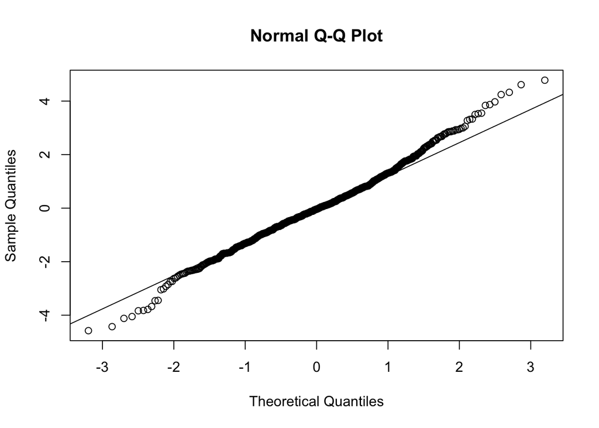

```r
#Tests normality of model2 residuals.
qqnorm(residuals(model2))
qqline(residuals(model2))
```

QQ-plot shows residuals are normally distributed as there is no strong S-shape, but rather a constant diagonal line. This satisfies the normality assumption for this LMM.

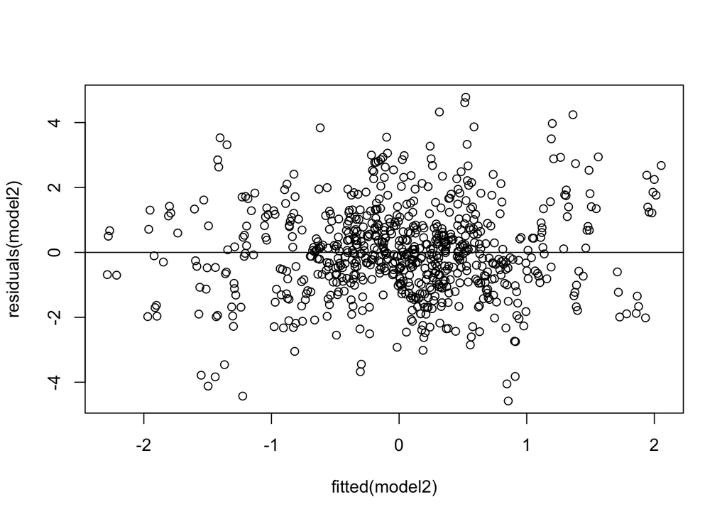

```r
#Tests model2 for homoscedasticity of variance.
plot(fitted(model2), residuals(model2))
abline(h = 0)
```

Residual plot has a horizontal shape. The lack of curvature and drift suggests fairly uniform variance, so no heterogeneity of variance. This indicates that the residuals are homoscedastic.

```r
#Compares model1 and model2, justifying the addition of random slopes in model2
anova(model1, model2)
```

```
## refitting model(s) with ML (instead of REML)
```

```
## Data: long_HEPdata
## Models:
## model1: HEP_mean_value ~ Condition * Time_Window + Channel + (1 | Participant)
## model2: HEP_mean_value ~ Condition * Time_Window + Channel + (1 + Time_Window | Participant)
##        npar    AIC    BIC  logLik -2*log(L)  Chisq Df Pr(>Chisq)
## model1   17 2726.7 2804.5 -1346.3    2692.7
## model2   19 2645.3 2732.3 -1303.7    2607.3 85.358  2  < 2.2e-16 ***
## ---
## Signif. codes:  0 '***' 0.001 '**' 0.01 '*' 0.05 '.' 0.1 ' ' 1
```

Model1 and Model2 were compared to determine which fit the data set best. Due to Model1 having higher AIC and BIC values, it is concluded that it under fits the data set. Model1 does not have enough complexity to fully capture the data. By taking into consideration that each participant has their own window response when comparing early vs. late windows, Model2 fits the data structure best.

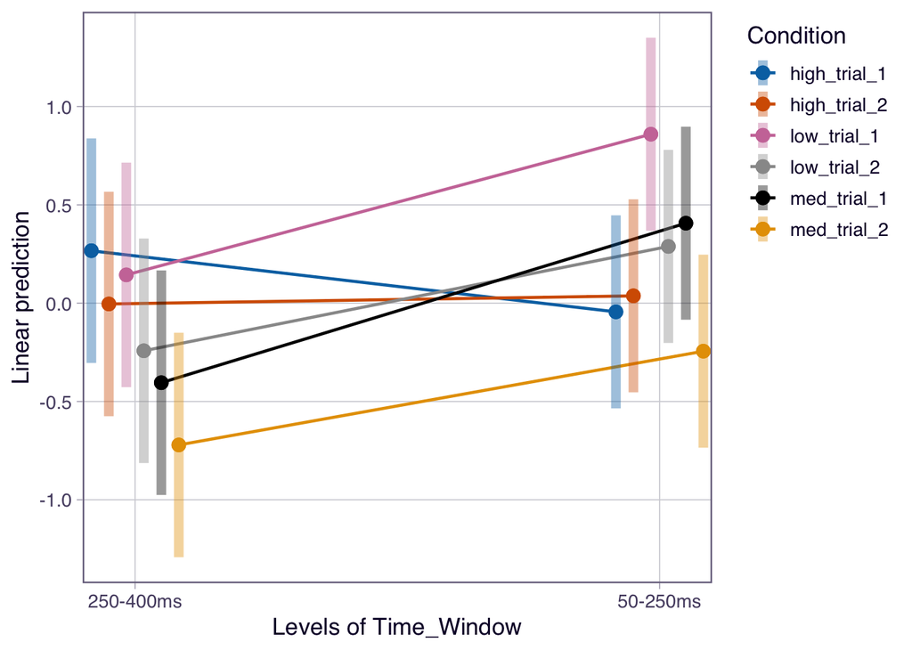

```r
#Generates an interaction plot to visualize estimated marginal means (EMMs) of the data.
emmip(
  model2,
  Condition ~ Time_Window,
  CIs = TRUE
)
```

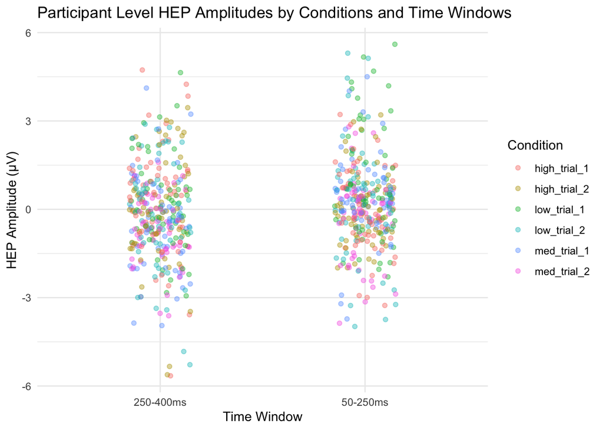

```r
#Generates a jitter plot to visualize the relationship between participant HEP amplitudes and condition x time window
ggplot(long_HEPdata,
       aes(Time_Window, HEP_mean_value, color=Condition))+
  geom_jitter(width=0.15, alpha=0.4) +
  theme_minimal(base_size = 16) +
  labs(
    title = "Participant Level HEP Amplitudes by Conditions and Time Windows",
    x = "Time Window",
    y = "HEP Amplitude (µV)"
  ) +
  theme_minimal()
```

Choice of Test: I chose to run a linear mixed-effects model with the fixed effects of Condition, Time Window, their interaction variable, and Channel. Due to the HEP data being collected repeatedly from the same participants over multiple trial conditions, the independence assumption is violated, so neither an ANOVA or linear regression can be performed. Mixed-effects modeling remains as the best choice as it accounts for individual-level variability and within-subject correlation. Diagnostic tests of assumptions performed on model2, QQ plot and residual plot, indicate the data does not deviate significantly from normality and is homoscedastic, thus further supporting the use of a mixed-effects model to analyze the data.